# Homework 2

# Submission Instructions

- Please submit your responses as a nicely formatted notebook (.ipynb) file.
- For questions that require calculations:
  - Show your work (i.e., show the R code you used to answer the question).
  - Make sure all the code you used to answer the question has been run (i.e., displays an output) otherwise you will get a zero for that question.
  - If your *answer* includes many decimal places (e.g., 3.14159265358979), please round it to a reasonable number of decimals for readability (typically 3 to 4).
  - There should be no rounding inside the calculations you do, only round the final result if necessary.
  - For ease of marking, avoid showing the outputs of unnecessary values (short meaningful comments `#` in your code are fine).
  - **If a function or package is prohibited, so are other functions and packages that perform equivalent calculations.**
  - Unless specified otherwise, assume $\alpha = 0.05$.

# Question 1

Calculate $\bar{x}$, $\text{ss}$, $s^2$, and $s$ of the following data. You are not allowed to use the functions `mean()`, `sd()`, or `var()`.

$$650, 670, 660, 669, 649, 668, 677, 651,
680, 663$$

```r
x <- c(650, 670, 660, 669, 649, 668, 677, 651, 680, 663)
n <- length(x)

# Mean
m <- sum(x)/n
round(m, 4)
```

```
## [1] 663.7
```

```r
# Sum of Squared Deviations
ss <- sum((x - m)^2)
round(ss, 4)
```

```
## [1] 1108.1
```

```r
# Variance
var <- ss/(n - 1)
round(var, 4)
```

```
## [1] 123.1222
```

```r
# Standard Deviation
s <- sqrt(var)
round(s, 4)
```

```
## [1] 11.096
```

# Question 2

Assuming the data from the previous question is normally distributed, calculate the points the middle 95% of the data fall within. Do not use the functions `pnorm()` or `qnorm()`; instead, use the values in the graph below (from the lecture) to determine the middle boundry.

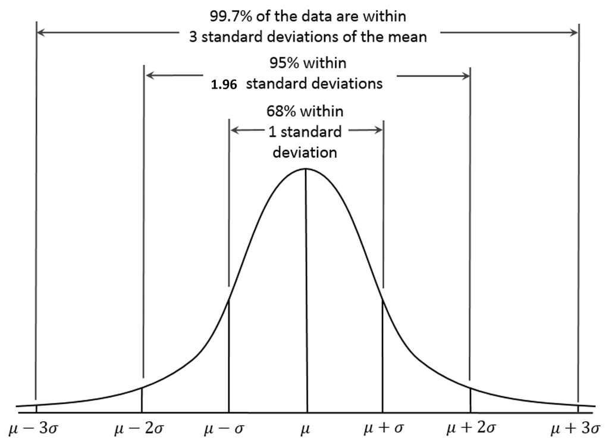

```r
# Lower Bound
lower <- m - 1.96 * s

# Upper Bound
upper <- m + 1.96 * s
```

```
## [1] "[641.9518, 685.4482]"
```

As a side note: if you would like to display the output as an interval like I have done, you can just use `paste0()` function:

```r
paste0("[", round(lower, 4), ", ", round(upper, 4), "]")
```

# Question 3

Assuming the data from question 1 is normally distributed, calculate the points the middle 68% of the data fall within. Do not use the functions `pnorm()` or `qnorm()`; instead, use the graph provided in the previous question.

```r
# Lower Bound
lower <- m - 1 * s

# Upper Bound
upper <- m + 1 * s
```

```
## [652.604, 674.796]
```

# Question 4

Use R code to calculate $\mu$, $\text{ss}$, $\sigma^2$, and $\sigma$ for the following distribution of numbers:

$$10, 10, 10, 10, 10, 10, 10, 10, 10,
10$$

Why do you think the answer turned out the way it did?

```r
x <- c(10, 10, 10, 10, 10, 10, 10, 10, 10, 10)
n <- length(x)

# Mean
m <- sum(x)/n
m
```

```
## [1] 10
```

```r
# Sum of Squared Deviations
ss <- sum((x - m)^2)
ss
```

```
## [1] 0
```

```r
# Variance
v <- ss/(n)
v
```

```
## [1] 0
```

```r
# Standard Deviation
s <- sqrt(v)
s
```

```
## [1] 0
```

> The data has no spread (i.e. does not vary/deviate); hence our statistical measures of spread (the sum of squared deviations, variance, and standard deviation) are just 0.

> Note: if you used `sd()` or `var()` in your R code, you did this wrong. Those functions calculate the sample standard deviation and sample variance, respectively.

# Question 5

Which of the following are measures of spread?

- Range
- IQR
- Quartiles
- Median
- Mean
- Sum of Squared Deviations
- Variance
- Standard Deviation
- Z-score

> Range, IQR, Sum of Squared Deviations, Variance, Standard Deviation.

# Question 6

Using the Son height data from the lecture, transform the sons’ scores to have a mean of 500 and a standard deviation of 500. Then plot a histogram of the new distribution with an interesting fill and edge colour. Label the x-axis and y-axis “*New Son Heights*” and “*Frequency*” respectively.

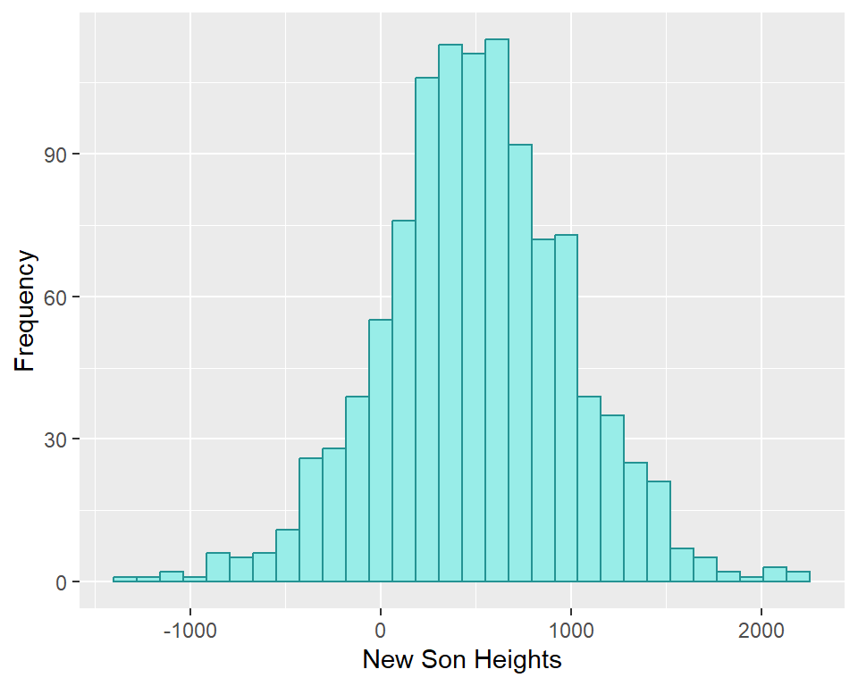

```r
library(tidyverse)
heights <- read_csv("../Data/PearsonHeightData.csv")

# Z-scores
heights$z_scores <- (heights$Son - mean(heights$Son)) / sd(heights$Son)

# New Scores
heights$son_t <- heights$z_scores * 500 + 500

# Plot
ggplot(heights, aes(x = son_t)) +
  geom_histogram(fill = "#98EDE8", colour = "#249393") +
  xlab("New Son Heights") +
  ylab("Frequency")
```

# Question 7

From the course website, download the dataset **Pokemon.csv**. This data set presents statistics for each of the pokémon characters in the popular video game franchise “Pokémon.”

Use this data set to plot a density plot for the variable “HP.” Give the density plot a fill colour of “Pikachu yellow”, which is defined by Nintendo as “#F6CF57.”

- HP stands for hit points, or health points, and defines how much damage a pokémon can withstand before fainting.
- Fun Fact: Some of the columns in this dataset contain Japanese characters. If you open this in Microsoft Excel, there is a good chance they won’t display properly. This is because, by default, Microsoft Excel does not read CSV files using [UTF-8 character encoding](https://blog.hubspot.com/website/what-is-utf-8) despite that being the accepted standard across the world. Why? I don’t know - but it is probably because they want you to use .xlsx files and simply don’t care about anything that isn’t owned by Microsoft. Note, if you want a spreadsheet software that will use UTF-8 character encoding by default, try [Libre Office](https://www.libreoffice.org/) or even Google Sheets.

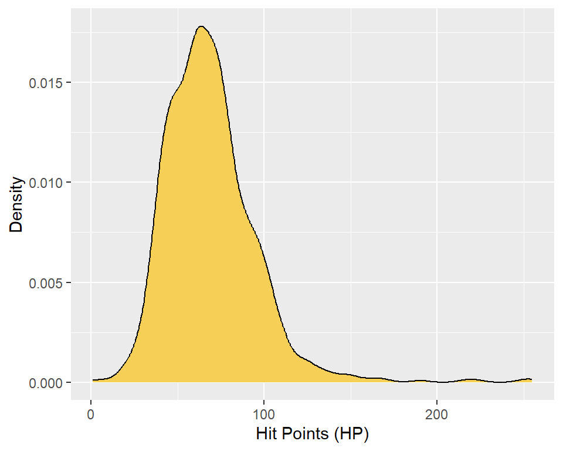

```r
poke <- read_csv("../Data/Pokemon.csv")
pikachu <- '#F6CF57'

ggplot(poke, aes(x = hp)) +
  geom_density(fill = pikachu, colour = "black") +
  xlab("Hit Points (HP)") +
  ylab("Density")
```

# Question 8

Plot a Q-Q plot of the pokémon HP column and indicate whether or not you believe the data is normally distributed (describe why you believe this - appeal to both the density and Q-Q plot).

Make sure the Q-Q-plot incorporates Pikachu yellow in some way.

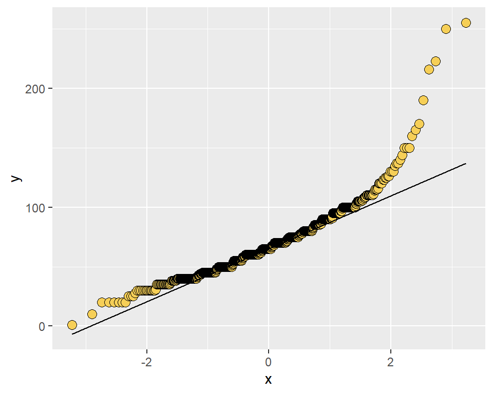

```r
ggplot(poke, aes(sample = hp)) +
  stat_qq(
    size = 3,
    shape = 21,
    fill = pikachu
  ) +
  stat_qq_line()
```

> The data is not acceptably normal. The density plot shows a long tail in the positive direction which indicates the presense of values that are likely to pull the mean and inflate the standard deviation. The Q-Q plot shows large portions of the ends of the distribution not aligning diagonally like you would expect normally distributed data to.

# Question 9

Use Tukey’s Ladder of Powers to find a transformation that makes the pokémon HP data more normal/Gaussian. Specify which value of lambda ($\lambda$) you used and plot a histogram of the transformed data. Ensure that your x-axis label communicates the transformation you applied.

- Note: the function `transformTukey()` is NOT allowed to be used for this question. You need to experiment and walk up/down the ladder yourself. (You do not need to show all your attempts, just show the final result).
- Note: An exhaustive search for the exact value of lambda is unnecessary. Use only the values provided in the lecture table.

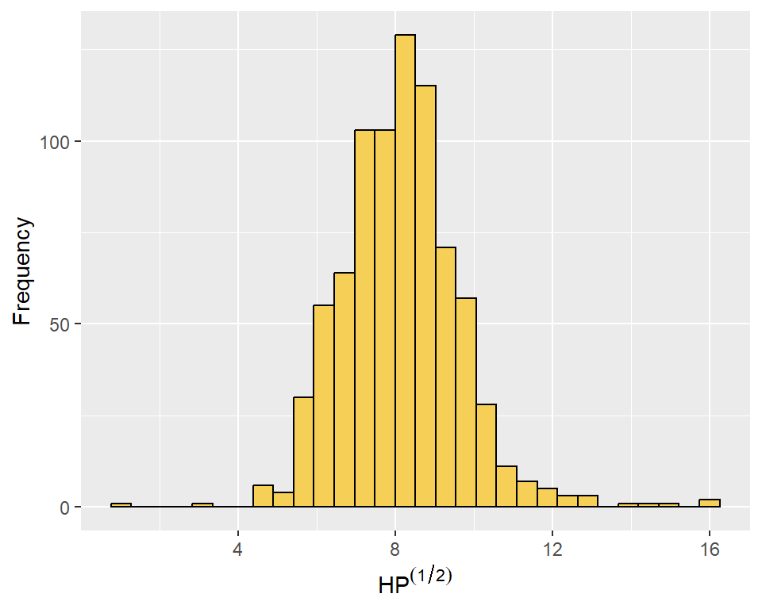

```r
poke$hp_t <- poke$hp^(1/2)

ggplot(poke, aes(x = hp_t)) +
  geom_histogram(fill = pikachu, colour = "black") +
  xlab(bquote(HP^(1 / 2))) +
  ylab("Frequency")
```

> The square root was used (a.k.a $\lambda = \frac{1}{2}$).
- Note that the cubic root is also an acceptable transformation (a.k.a $\lambda = \frac{1}{3}$).
- FYI: The function `bquote()` is useful for incorporating mathematical statements into your labels.

# Question 10

Plot a Q-Q plot of your transformed pokémon HP data. Use it and the plot from the previous question to determine whether you believe the transformed data is now acceptably normal. Hint: the answer is no. Justify your answer.

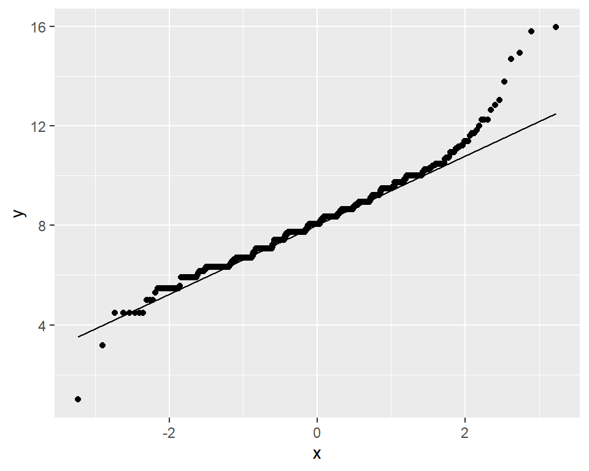

```r
ggplot(poke, aes(sample = hp_t)) +
  stat_qq() +
  stat_qq_line()
```

> While there is some improvement, the data is still not acceptably normal since, in both the histogram and Q-Q plot, you can see very extreme outlying values which are probably inflating the standard deviation and shifting the mean.

# Question 11

For the variable HP, calculate the following statistics using the original (untransformed) pokémon data:

- Mean
- Sample Standard Deviation

You are not allowed to use the `mean()`, `var()`, or `sd()` functions.

```r
# Sample Size
N <- length(poke$hp)

# Mean
m <- sum(poke$hp) / N
m
```

```
## [1] 68.9588
```

```r
# Standard Deviation
s <- sqrt(sum((poke$hp - m)^2) / (N - 1))
s
```

```
## [1] 26.57601
```

# Question 12

For the variable HP, calculate the following statistics using the original (untransformed) pokémon data:

- 20% Trimmed Mean
- 20% Winsorized Standard Deviation

You are not allowed to use the `mean()`, `winvar()`, or `winse()` functions.

```r
# Sample Size
N <- length(poke$hp)

# Sort data
hp <- sort(poke$hp)

# Amount of values to remove from each side
trim <- floor(N * 0.20)

# Subset rows to keep
hp_trim <- hp[(trim + 1) : (N - trim)]

# 20% Trimmed mean
sum(hp_trim) / length(hp_trim)
```

```
## [1] 66.09563
```

```r
# Add winsorized values to trimmed data
hp_win <- c(
  hp_trim,
  rep(min(hp_trim), trim), # repeating the min value
  rep(max(hp_trim), trim) # repeating the max value
)

# 20% Winsorized Standard Deviation
sd(hp_win)
```

```
## [1] 14.44225
```

# Question 13

Without using the R function `mad()`, list the values considered outliers for the untransformed pokémon HP data according to the MAD-median rule for outlier detection.

When listing the outliers, only display the following columns in this order: `$name`, `$pokedex_number`, and `$hp`.

**Note: there are numerous different methods for selecting columns. Below is an elegant *tidyverse* method.**

```r
med_hp <- median(poke$hp)
MADN <- median(abs(poke$hp - med_hp)) / 0.6745
poke$hp_out <- abs(poke$hp - med_hp) / MADN > 2.24

poke |>
  filter(hp_out == TRUE) |> # grab outlier rows
  select(name, pokedex_number, hp) #choose columns to display
```

```
## # A tibble: 35 × 3
##    name       pokedex_number    hp
##    <chr>               <dbl> <dbl>
##  1 Jigglypuff             39   115
##  2 Wigglytuff             40   140
##  3 Diglett                50    10
##  4 Chansey               113   250
##  5 Lapras                131   130
##  6 Vaporeon              134   130
##  7 Snorlax               143   160
##  8 Lanturn               171   125
##  9 Wobbuffet             202   190
## 10 Blissey               242   255
## 11 Entei                 244   115
## 12 Slaking               289   150
```

[output cut: 23 more lines]

# Question 14

Use the R functions `pnorm()` and `qnorm()` to answer questions a - p.

- Note that there are multiple correct ways to apply these functions for some of the questions.

## a.

What percentile is a z-score of 0 at?

```r
pnorm(0, mean = 0, sd = 1) * 100
```

```
## [1] 50
```

## b.

What percentile is a z-score of -1.96 at?

```r
pnorm(-1.96, mean = 0, sd = 1) * 100
```

```
## [1] 2.49979
```

## c.

What percentile is a z-score of 1.96 at?

```r
pnorm(1.96, mean = 0, sd = 1) * 100
```

```
## [1] 97.50021
```

## d.

What probability does a z-score of 1.96 correspond to?

```r
pnorm(1.96, mean = 0, sd = 1)
```

```
## [1] 0.9750021
```

## e.

What percentile is a score of 202 at for a normal distribution with a mean of 224 and standard deviation of 29?

```r
pnorm(202, mean = 224, sd = 29) * 100
```

```
## [1] 22.40397
```

## f.

What percentile is a score of 224 at for a normal distribution with a mean of 224 and standard deviation of 29?

```r
pnorm(224, mean = 224, sd = 29) * 100
```

```
## [1] 50
```

## g.

What score is at the 2.5th percentile for a normal distribution with a mean of 224 and standard deviation of 29?

```r
qnorm(0.025, mean = 224, sd = 29)
```

```
## [1] 167.161
```

## h.

What score is at the 97.5th percentile for a normal distribution with a mean of 224 and standard deviation of 29?

```r
qnorm(0.975, mean = 224, sd = 29)
```

```
## [1] 280.839
```

## i.

What z-score represents the 2.5th percentile?

```r
qnorm(0.025, mean = 0, sd = 1)
```

```
## [1] -1.959964
```

## j.

z-score represents the top 2.5% of a normal distribution?

```r
qnorm(0.025, mean = 0, sd = 1, lower.tail = FALSE)
```

```
## [1] 1.959964
```

## k.

What z-score is at the 97.5th percentile?

```r
qnorm(0.975, mean = 0, sd = 1)
```

```
## [1] 1.959964
```

## l.

What score represents the top 2.5% of a normal distribution with a mean of 224 and standard deviation of 29?

```r
qnorm(0.025, mean = 224, sd = 29, lower.tail = FALSE)
```

```
## [1] 280.839
```

## m.

What score represents the top 5% of a normal distribution with a mean of 224 and standard deviation of 29?

```r
qnorm(0.05, mean = 224, sd = 29, lower.tail = FALSE)
```

```
## [1] 271.7008
```

## n.

What z-score represents the top 5% of a normal distribution?

```r
qnorm(0.05, mean = 0, sd = 1, lower.tail = FALSE)
```

```
## [1] 1.644854
```

## o.

What score represents the top 5% of a normal distribution with a mean of 132 and standard deviation of 57?

```r
qnorm(0.05, mean = 132, sd = 57, lower.tail = FALSE)
```

```
## [1] 225.7567
```

## p.

What score represents the bottom 9.3% of a normal distribution with a mean of 132 and standard deviation of 57?

```r
qnorm(0.093, mean = 132, sd = 57)
```

```
## [1] 56.61721
```

# Question 15

Which distribution contains the largest spread/variability?

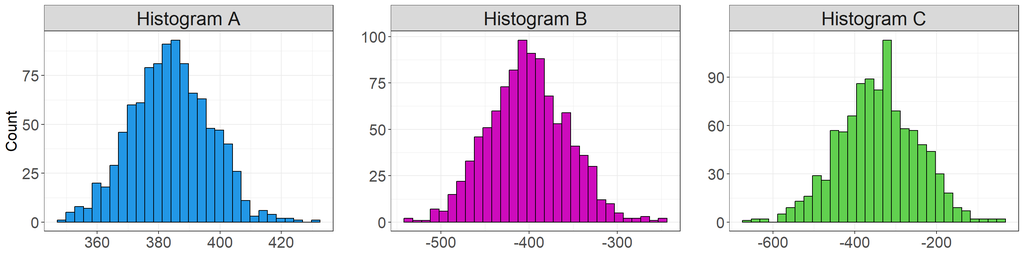

Histogram C

To discern the answer, you need to gauge the scale of the x-axis.

# Question 16

The following plot is a standard normal distribution. What percentile is represented by the coloured (non-grey) region.

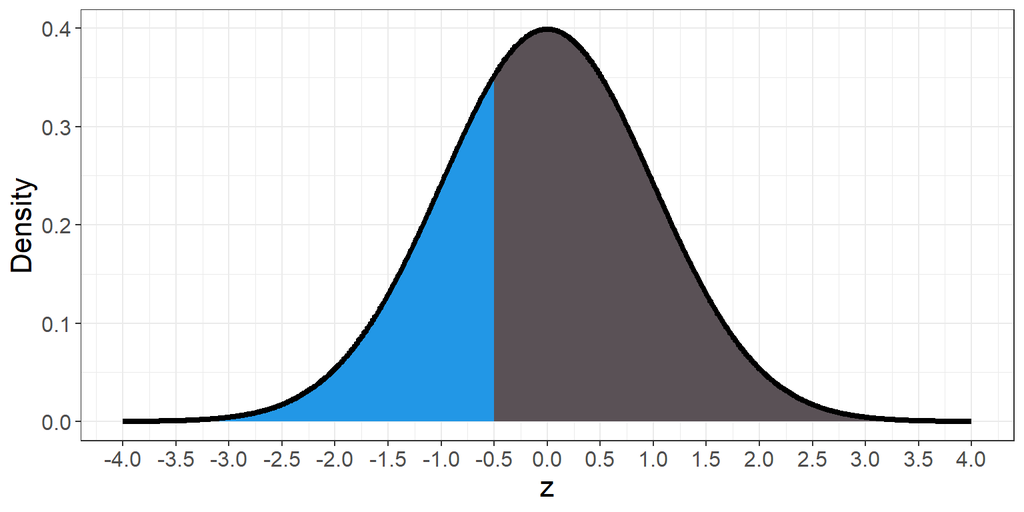

```r
pnorm(-0.5, mean = 0, sd = 1) * 100
```

```
## [1] 30.85375
```

# Question 17

The following plot is a standard normal distribution. What percentile is represented by the coloured (non-grey) region.

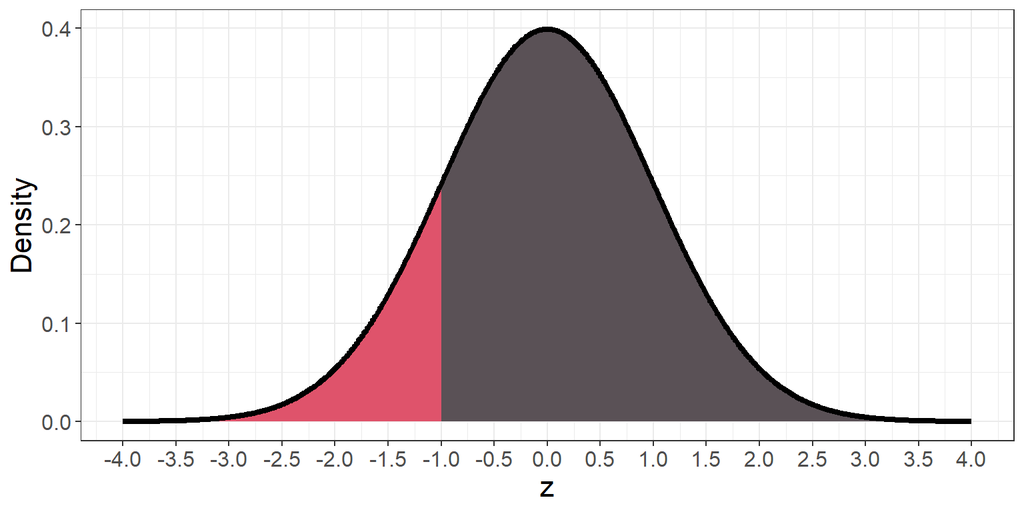

```r
pnorm(-1, mean = 0, sd = 1) * 100
```

```
## [1] 15.86553
```

# Question 18

The following distribution has a mean of 100 and standard deviation of 15. What percentile is represented by the coloured (non-grey) region.

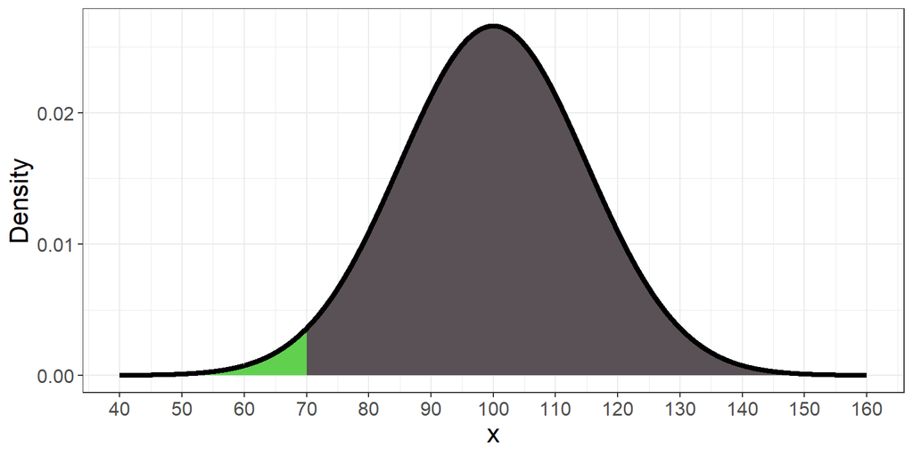

```r
pnorm(70, mean = 100, sd = 15) * 100
```

```
## [1] 2.275013
```

# Question 19

The following distribution has a mean of 100 and standard deviation of 15. What percentage of the data is represented by the coloured (non-grey) region.

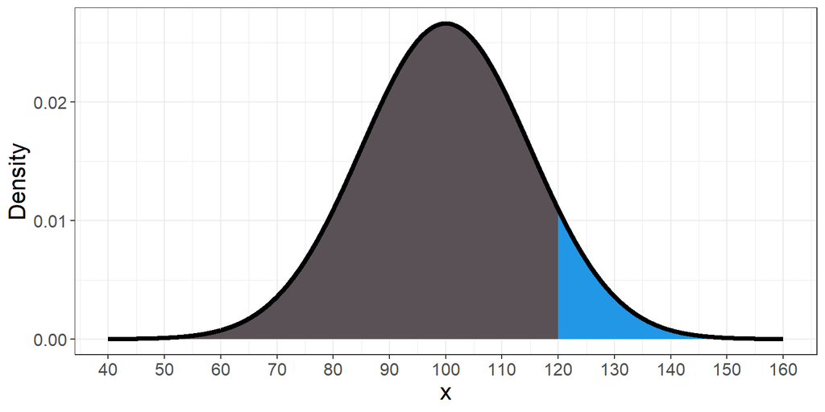

```r
pnorm(120, mean = 100, sd = 15, lower.tail = FALSE) * 100
```

```
## [1] 9.121122
```

# Question 20

Bobby’s brother constantly tells him he’s abnormal. To prove this, his brother obtained a sample of test scores from Bobby’s class (Bobby was included in this sample). His classmates’ scores were 70, 68, 75, 72, 76, 74, 69, 82, 73, and Bobby scored a 56. If “abnormal” is operationally defined as being at least 2 standard deviations away from the mean, is Bobby abnormal? Assume the data follows a normal distribution.

```r
bobby <- 56
class <- c(70, 68, 75, 72, 76, 74, 69, 82, 73, bobby)
n <- length(class)
m <- mean(class)
s <- sd(class)

bobby_z <- (bobby - m) / s
bobby_z
```

```
## [1] -2.289502
```

> A z-score shows Bobby to be 2.29 standard deviations below the mean. Therefore, Bobby’s brother is (technically) correct. Bobby is abnormal.

> Note: that this could have also been solved by calculating an interval spanning $\pm$ 2 standard deviations.

# Question 21

From the previous question, what is the probability of a student scoring at Bobby’s mark or less?

```r
bob_prob <- pnorm(bobby, mean = m, sd = s)
bob_prob
```

```
## [1] 0.01102511
```

# Question 22

What is the probability of a student scoring higher than Bobby?

```r
1 - bob_prob
```

```
## [1] 0.9889749
```

# Question 23

We have sent out everyone in a large introductory course to check whether people use seat belts. Each student has been told to look at 100 cars and count the number of people wearing seat belts. The number found by any given student is considered that student’s score. The mean score for the class is 44, with a standard deviation of 7. A student who has done very little work all year has reported finding 62 seat belt users out of 100. Do we have reason to suspect that the student just made up a number rather than actually counting? Assume the data collected by the class follows a normal distribution.

```r
p <- pnorm(62, mean = 44, sd = 7)
p
```

```
## [1] 0.994936
```

> The student’s score of 62 is at, approximately, the 99th percentile, which is exceedingly rare given all the other data collected. It seems very likely the student fabricated their answer.

> *Other possible ways of solving this:*

> > You could compute a z-score. A z-score that is greater than 1.96 (or 2) standard deviations from the mean would (according to common convention) indicate a statistically rare value and thus suggest the student made up the number.

```r
z <- (62 - 44) / 7
z
```

```
## [1] 2.571429
```

> > You could compute a interval encompassing the middle 95% of the data. If the student’s score of 62 falls outside of that range, it’s probably fabricated. i.e.,

```r
lower <- 44 - 1.96 * 7
upper <- 44 + 1.96 * 7
```

```
## [30.28, 57.72]
```

# Question 24

From the previous question, what is the minimum and maximum number of seatbelts that could have been “observed” by this student without drawing suspicion? Assume anything in the top and bottom 2.5% of the distribution is suspicious. Round to the nearest seatbelt.

```r
#Min (bottom 2.5%)
round(qnorm(p = 0.025, mean = 44, sd = 7))
```

```
## [1] 30
```

```r
#Max (top 2.5%)
round(qnorm(p = 0.975, mean = 44, sd = 7))
```

```
## [1] 58
```

> The minimum is 30 and the maximum is 58.

# Question 25

A researcher counted the number of behavioural responses a sample of participants completed during a period of operant extinction (i.e., the participaints were no longer reinforced/rewarded to perform a task). The data was positively skewed but the researcher nonetheless analyzed the results in terms of means and standard deviations. They reported a mean of $5.88$ and a standard deviation of $8.06$. Why was this an incredibly stupid way to analyze the results? Hint: consider where $0$ responses might fall if this distribution was symmetric and unimodal.

```r
resp <- pnorm(q = 0, mean = 5.88, sd = 8.06)
resp
```

```
## [1] 0.2328392
```

> Using means and standard deviations assumes the data is symmetric. Given the mean and standard deviation they report, approximately 23% of their data must be falling below 0. This implies that they observed participaints completing negative amounts of responding! That doesn’t make any sense.

# Question 26

Recall that, for question 2 and 3 you needed to calculate the middle 95% and middle 68% boundries for the following data:

$$650, 670, 660, 669, 649, 668, 677, 651,
680, 663$$

Do that again, but this time use R functions to obtain a more precise calculation instead of using the values in the graph that was provided.

```r
x <- c(650, 670, 660, 669, 649, 668, 677, 651, 680, 663)

n <- length(x)
m <- mean(x)
s <- sd(x)

# Middle 95% (2.5% in the tails)
lower_95 <- qnorm(.025, mean = m, sd = s)
upper_95 <- qnorm(.025, mean = m, sd = s, lower.tail = FALSE)

# Middle 68% (16% in the tails)
lower_68 <- qnorm(0.16, mean = m, sd = s)
upper_68 <- qnorm(0.16, mean = m, sd = s, lower.tail = FALSE)
```

```r
# Middle 95%
```

```
## [641.9522, 685.4478]
```

```r
# Middle 68%
```

```
## [652.6655, 674.7345]
```

# Question 27

In a normal distribution, how many standard deviations above and below the mean are the upper and lower boundaries of the middle 68% interval? Give an answer rounded to at least 4 decimal places.

```r
q <- abs(qnorm(0.16, mean = 0, sd = 1))
q
```

```
## [1] 0.9944579
```

# Question 28

Use the R functions `qnorm()`, `pnorm()`, `qt()`, and `pt()` to answer questions a - l.

## a.

What t-score indicates the 50th percentile for a t-distribution with a degrees of freedom of 13?

```r
qt(0.5, df = 13)
```

```
## [1] 0
```

## b.

What t-score represents the 75th percentile for a t-distribution with 13 degrees of freedom?

```r
qt(0.75, df = 13)
```

```
## [1] 0.6938293
```

## c.

What z-scores represents the middle 95% of a normal distribution?

```r
# Lower Bound
round(qnorm(0.025, mean = 0, sd = 1), 5)
```

```
## [1] -1.95996
```

```r
# Upper Bound
round(qnorm(0.025, mean = 0, sd = 1, lower.tail = FALSE), 5)
```

```
## [1] 1.95996
```

## d.

What t-scores represents the middle 99% of a t-distribution with 22 degrees of freedom?

```r
# Lower Bound
qt(0.005, df = 22)
```

```
## [1] -2.818756
```

```r
# Upper Bound
qt(0.005, df = 22, lower.tail = FALSE)
```

```
## [1] 2.818756
```

## e.

What t-score represents the 2.5th percentile of a t-distribution with 22 degrees of freedom?

```r
qt(0.025, df = 22)
```

```
## [1] -2.073873
```

## f.

What z-score represents the top 2.5% of a normal distribution?

```r
qnorm(0.025, mean = 0, sd = 1, lower.tail = FALSE)
```

```
## [1] 1.959964
```

## g.

What t-score represents the top 2.5% of a t-distribution with 1000 degrees of freedom?

```r
qt(0.025, df = 1000, lower.tail = FALSE)
```

```
## [1] 1.962339
```

## h.

What percentile does a t-score of -1.9 represent, for a t-distribution with 13 degrees of freedom?

```r
pt(-1.9, df = 13) * 100
```

```
## [1] 3.992069
```

## i.

What percentile does the value 120 represent, for a normal distribution with a mean of 100 and a standard deviation of 15?

```r
pnorm(120, mean = 100, sd = 15) * 100
```

```
## [1] 90.87888
```

## j.

What is the 17th percentile, for a normal distribution with a mean of 100 and a standard deviation of 15?

```r
qnorm(0.17, mean = 100, sd = 15)
```

```
## [1] 85.68752
```

## k.

What is the 42nd percentile, for a normal distribution with a mean of 48 and a standard deviation of 72?

```r
qnorm(0.42, mean = 48, sd = 72)
```

```
## [1] 33.46367
```

## l.

What value represents the boundary of the top 64% percent of a t-distribution with 94 degrees of freedom?

```r
qt(0.64, df = 94, lower.tail = FALSE)
```

```
## [1] -0.3595368
```

# Question 29

Use the following *sampled* data to answer questions a - g:

-54, -126, -92, -109, -113, -94, -110, -87, -83, -82, -85, -111, -74, -123, -89, -101, -97, -113, -77, -99, -90, -103, -116, -98, -81, -88, -97, -117, -95, -104, -111, -84, -125, -59, -97

## a.

Determine if it is reasonable to assume that the population is normally distributed based on the sample data.

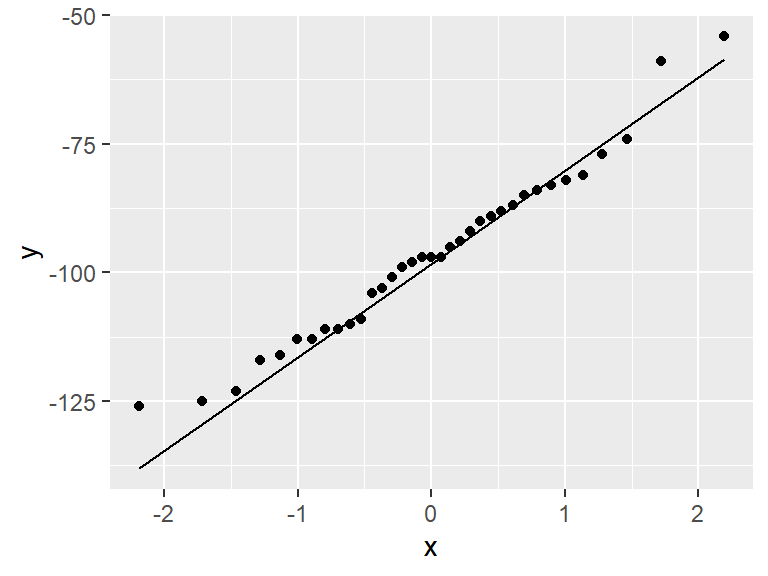

```r
library(tidyverse)

x <- c(
  -54, -126, -92, -109, -113, -94, -110, -87, -83, -82,
  -85, -111, -74, -123, -89, -101, -97, -113, -77, -99,
  -90, -103, -116, -98, -81, -88, -97, -117, -95, -104,
  -111, -84, -125, -59, -97
)

ggplot(mapping = aes(sample = x)) +
  stat_qq() +
  stat_qq_line()
```

> The assumption of a normally distributed population seems reasonable.

*Note for grading: Evaluation of normality needs to include, at a minimum, a Q-Q plot.*

## b.

Without using the functions `mean()`, `var()`, or `sd()`, calculate the sample size, mean, standard deviation, and standard error of the mean.

```r
# Sample Size:
N <- length(x)
N
```

```
## [1] 35
```

```r
# Mean
m <- sum(x) / N
round(m, 4)
```

```
## [1] -96.6857
```

```r
# Standard Deviation
s <- sqrt(sum((x - m)^2) / (N - 1))
round(s, 4)
```

```
## [1] 17.0859
```

```r
# Standard Error
se <- s/sqrt(N)
round(se, 4)
```

```
## [1] 2.888
```

## c.

If $H_0: \mu = -90$, calculate a 95% confidence interval to test this hypothesis. Do you reject the hypothesis (explain your reasoning in terms of the confidence interval)? You are not permitted to use the function `t.test()` to answer this question.

```r
df <- N - 1

alpha <- 0.05
t_crit <- abs(qt(alpha/2, df = df))

lower <- m - t_crit * se
upper <- m + t_crit * se
```

```
## [-102.5549, -90.8165]
```

> Since $\mu = -90$ is found outside the interval $[ -102.555 , -90.817 ]$, we reject $H_0$.

## d.

If $\alpha = 0.05$, calculate a p-value to test $H_0: \mu = -90$. Do you reject the hypothesis? You are not permitted to use the function `t.test()`.

```r
# Test Statistic
mu <- -90
test_stat <- (m - mu) / se
round(test_stat, 4)
```

```
## [1] -2.315
```

```r
# p-value
# Note: since the test statistic is negative (i.e., the sample mean is less
# than mu) we need to calculate the probability from left to right.
p <- pt(test_stat, df = df) * 2
round(p, 4)
```

```
## [1] 0.0268
```

> Since $p = 0.027$ is less than $\alpha = 0.05$, we reject $H_0$.

## e.

Repeat question c. testing $H_0: \mu \geq -90$. You are not permitted to use the function `t.test()`.

```r
# Recall that one-sided confidence intervals are
  # expressed in terms of the alternative hyp. (mu < -90)

# Critical t
t_crit <- abs(qt(alpha, df = df))

lower <- m - Inf * se
upper <- m + t_crit * se
```

```
## (-Inf, -91.8023]
```

> Since $\mu = -90$ is found outside the interval $( -\infty{} , -91.802 ]$, we reject $H_0$.

## f.

Repeat question d. testing $H_0: \mu \geq -90$. You are not permitted to use the function `t.test()`.

```r
# p-value:
# Note: To reject this hypothesis we need to find a value smaller than -90,
# which means the critical (rejection) region is in the left tail, and thus
# we calculate the p-value from left to right again.

p <- pt(test_stat, df = df)
round(p, 4)
```

```
## [1] 0.0134
```

> Since $p = 0.013$ is less than $\alpha = 0.05$, we reject $H_0$.

## g.

Use the function `t.test()` to test the hypothesis $H_0: \mu \geq -90$. $\alpha = 0.05$

```r
t.test(x, mu = mu, alternative = c("less"))
```

```
##
##  One Sample t-test
##
## data:  x
## t = -2.315, df = 34, p-value = 0.01339
## alternative hypothesis: true mean is less than -90
## 95 percent confidence interval:
##       -Inf -91.80225
## sample estimates:
## mean of x
## -96.68571
```

# Question 30

If you get a sample mean of 45 based on 25 participants and the sample standard deviation is 5, what is the two-sided 95% confidence interval? Assume random sampling from a normally distributed population.

```r
N <- 25
m <- 45
s <- 5
df <- N - 1
se <- s/sqrt(N)

alpha <- 0.05
t_crit <- abs(qt(alpha/2, df = df))

lower <- m - t_crit * se
upper <- m + t_crit * se
```

```
## [42.9361, 47.0639]
```

# Question 31

Repeat the previous question, except compute a two-sided 99% confidence interval.

```r
alpha <- 0.01
t_crit <- abs(qt(alpha/2, df = df))

lower <- m - t_crit * se
upper <- m + t_crit * se
```

```
## [42.2031, 47.7969]
```

# Question 32

A behavioural psychologist claims that, on average, a specific reinforcement schedule results in rats pressing a lever approximately 1,200 times over the course of a 60-minute session. You conduct an experiment with 36 randomly selected rats trained under the same conditions and observe a mean of 1,150 lever presses, with a standard deviation of 25.

Does a 95% confidence interval cast doubt on the psychologist’s claim? Assume the number of lever presses is normally distributed.

```r
N <- 36
m <- 1150
s <- 25
df <- N - 1
se <- s/sqrt(N)

alpha <- 0.05
t_crit <- abs(qt(alpha/2, df = df))

lower <- m - t_crit * se
upper <- m + t_crit * se
```

```
## [1141.541, 1158.459]
```

> Yes the interval suggests the claim is unreasonable. The researcher’s value 1200 falls outside of the 95% confidence interval.

# Question 33

If $N = 10$ observations are randomly sampled from a normal distribution with $\mu = 9$ and $\sigma = 8$, what is the mean and standard deviation of the *sampling distribution* of the mean?

```r
N <- 10
m <- 9
s <- 8
se <- s / sqrt(N) # Standard error is the std. dev of the sampling dist.
round(se, 4)
```

```
## [1] 2.5298
```

> The mean of the sampling distribution is 9 and the standard deviation of the sampling distribution (i.e., the standard error) is 2.53.

# Question 34

What is the variance of the sampling distribution from the previous question?

```r
var <- s^2 / N
# or
var <- (s / sqrt(N))^2

round(var, 4)
```

```
## [1] 6.4
```

# Question 35

Given that $\bar{x} = 78$, $s = 25$, $N = 10$, and $\alpha = 0.05$, test the hypothesis that $H_0: \mu > 80$. Assume observations are randomly sampled from a normal distribution.

Report:

- the test statistic
- degrees of freedom
- confidence interval
- p-value
- whether your reject or fail to reject the $H_0$

```r
mu <- 80
m <- 78
s <- 25
N <- 10
se <- s/sqrt(N)
df <- N - 1

# Confidence Interval
alpha <- 0.05
t_crit <- abs(qt(alpha, df = df))
low_ci <- m - Inf * se
top_ci <- m + t_crit * se

# P-value
t <- (m - mu) / se
p <- pt(t, df = df)
```

```
## Test statistic: -0.253
```

```
## df = 9
```

```
## (-Inf, 92.492]
```

```
## p = 0.403
```

> Since 80 ($\mu_0$) is contained within the confidence interval, we fail to reject.

> … Or … since p > 0.05, we fail to reject.

# Question 36

Repeat the previous question, but test $H_0: \mu = 80$.

```r
# Confidence Interval
t_crit <- abs(qt(alpha / 2, df = df))
low_ci <- m - t_crit * se
top_ci <- m + t_crit * se

# P-value
p <- pt(t, df = df) * 2
```

```
## Test statistic: -0.253
```

```
## df = 9
```

```
## 95% CI = [60.1161, 95.8839]
```

```
## p = 0.806
```

> Since 80 ($\mu_0$) is contained within the confidence interval, we fail to reject.

> … Or … since p > 0.05, we fail to reject.

# Question 37

Assume you have the following data:

94, 94, 74, 103, 121, 77, 117, 89, 101, 97, 95, 119, 100, 145, 111, 88, 81, 103, 126, 97, 88, 83, 128, 77, 129

If $H_0: \mu \geq 110$, compute a one-sided 95% confidence interval and evaluate whether you should reject $H_0$.

- Use of `t.test()` is not permitted.

```r
x <- c(
  94, 94,  74,  103, 121, 77, 117, 89,  101, 97,
  95, 119, 100, 145, 111, 88, 81,  103, 126, 97,
  88, 83,  128, 77, 129
)

N <- length(x)
m <- mean(x)
se <- sd(x) / sqrt(N)
df <- N - 1

alpha <- 0.05
t_crit <- abs(qt(alpha, df = df))

# CI boundary
lower <- m - Inf * se
upper <- m + t_crit * se
```

```
## (-Inf, 107.8854]
```

> Since $110$ is not contained within the interval we reject $H_0$.

# Question 38

Using the previous question’s data, what is the 95% confidence interval if $H_0: \mu \leq 90$? Do you reject $H_0$?

```r
alpha <- 0.05
t_crit <- abs(qt(alpha, df = df))

# CI boundary
lower <- m - t_crit * se
upper <- m + Inf * se
```

```
## [95.0746, Inf)
```

> Since $90$ is not contained within the interval we reject $H_0$.

# Question 39

What determines which side infinity ($\infty$) falls on in a one-sided confidence interval? Is it the significance of the test or the direction of the hypothesis?

> Direction of the hypothesis.

> > Tip: the interval will always be expressed in terms of the alternative hypothesis.

# Question 40

On the course website you will find a data set called **AllTimeMovies.csv**. It contains the top 79 all-time movies as of 2003 by domestic (US) gross receipts. Evaluate whether domestic (US) gross is normally distributed.

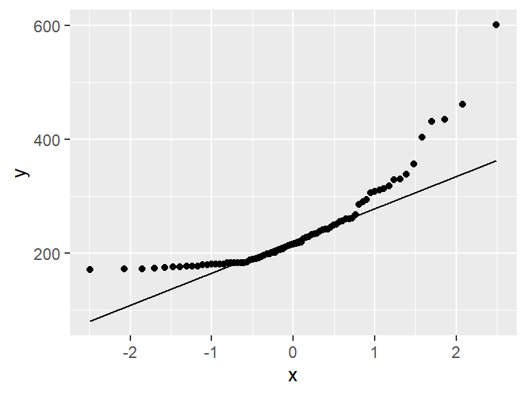

```r
movies <- read_csv("../Data/AllTimeMovies.csv")

ggplot(movies, aes(sample = Gross)) +
  stat_qq() +
  stat_qq_line()
```

> The points show a systematic departure from a straight line, meaning it is not reasonable to assume this data is normally distributed.

*Note for grading: Evaluation of normality needs to include, at a minimum, a Q-Q plot.*

# Question 41

Using the data set **AllTimeMovies.csv**, calculate a two-sided 95% confidence interval on the trimmed mean for the movies’ domestic (US) gross. Use 20% trimming.

```r
library(WRS2)

# Sample Size
N <- length(movies$Gross)

# Amount of Trimming
G <- 0.2

# Trimmed mean
m <- mean(movies$Gross, tr = G)

# Winsorized Variance and Standard Deviation
var <- winvar(movies$Gross, tr = G)
s <- sqrt(var)

# Standard Error of Trimmed Mean
se <- s / ((1-2*G) * sqrt(N))

# Degrees of Freedom
h <- N - 2 * floor(G * N)
df <- h - 1

# Critical T
alpha <- 0.05
t_crit <- abs(qt(alpha/2, df = df))

lower <- m - t_crit * se
upper <- m + t_crit * se
```

```
## [204.3407, 235.7817]
```

# Question 42

Using the movie data from the previous question, test $H_0: \mu = 240.19$ using $20\%$ trimmed means.

Report:

- the test statistic
- degrees of freedom
- p-value
- whether your reject or fail to reject the $H_0$

```r
mu <- 240.19
t <- (m - mu) / se

p <- pt(t, df = df) * 2
```

```
## Test statistic: -2.5744
```

```
## df = 48
```

```
## p = 0.0132
```

```
## Since p < .05 we reject the null hypothesis.
```

# Question 43

A researcher claims that, on average, 45% of toddlers aged 18–24 months can correctly identify basic emotions (e.g., happy, sad, angry) from facial expressions shown in picture books. You conduct a study with 10 randomly selected toddlers in that age range and record the percentage of correctly identified emotions for each child:

38, 44, 62, 72, 43, 40, 43, 42, 39, 41

Assuming the data come from a normally distributed population, test the hypothesis that the true average percentage of correct identifications is 45%, using a significance level of $\alpha = 0.01$. Calculate both a p-value and a 99% confidence interval. Assume observations are randomly sampled from a normally distributed population. Do not use `t.test()`.

Make sure to report:

- the test statistic
- degrees of freedom
- Confidence interval
- p-value
- whether your reject or fail to reject the $H_0$

```r
data <- c(38, 44, 62, 72, 43, 40, 43, 42, 39, 41)
mu <- 45

m <- mean(data)
s <- sd(data)
N <- length(data)
se <- s/sqrt(N)

# Degrees of Freedom
df <- N - 1

# Critical T-value
alpha <- 0.01
t_crit <- abs(qt(alpha / 2, df = df))

# Test statistic
t <- (m - mu)/se

# P-value
p <- pt(t, df = df, lower.tail = FALSE) * 2

# 99% Confidence Interval
CI_bottom <- m - t_crit * se
CI_top <- m + t_crit * se
```

```
## Test statistic: 0.393
```

```
## df = 9
```

```
## 99% CI = [34.8216, 57.9784]
```

```
## p = : 0.7035
```

```
## Since p > .05 we fail to reject
```

# Question 44

Use the R function `t.test()` to calculate the previous question’s answer.

```r
t.test(data, mu = 45, alternative = c("two.sided"), conf.level = .99)
```

```
##
##  One Sample t-test
##
## data:  data
## t = 0.39295, df = 9, p-value = 0.7035
## alternative hypothesis: true mean is not equal to 45
## 99 percent confidence interval:
##  34.82158 57.97842
## sample estimates:
## mean of x
##      46.4
```

# Question 45

Recalculate the confidence interval and p-value for the previous question with the hypothesis $H_0: \mu > 45$. Do not use `t.test()`.

```r
# Confidence Interval
t_crit <- abs(qt(alpha, df = df))
CI_bottom <- m - Inf * se
CI_top <- m + t_crit * se

paste0("99% CI = ", "(", round(CI_bottom, 4), ", ", round(CI_top, 4), "]")
```

```
## [1] "99% CI = (-Inf, 56.4521]"
```

```r
# p-value
p <- pt(t, df = df)
round(p, 4)
```

```
## [1] 0.6483
```

*Note for grading: use of `paste0()` to display the interval is not necessary.*

# Question 46

Calculate an appropriate effect size for the previous analysis. Interpret what this effect size tells us about the magnitude of the effect (be specific). Do not use `cohen.d()`.

```r
# Note: because of the small sample (N < 50) we need to apply Hedge's correction
# (i.e., calculate Hedge's g)

# Cohen's d
d <- (m - mu) / s

# Hedge's g
g <- d * (1 - (3 / (4 * N - 9)))
g
```

```
## [1] 0.1122371
```